# Risk Factor Analysis

## Outcome Variable

**Outcome Variable:** ever_co

## Predictor Variables

**Intervention Variable:** mwtkg

**Adjustment Set:**

unadjusted

## Stratifying Variables

The analysis was stratified on these variable(s):

- agecat
- studyid
- country

## Data Summary

| agecat | studyid | country | mwtkg | ever_co | n_cell | n |
| --- | --- | --- | --- | --- | --- | --- |
| 0-24 months | ki0047075b-MAL-ED | BANGLADESH | >=58 kg | 0 | 45 | 254 |
| 0-24 months | ki0047075b-MAL-ED | BANGLADESH | >=58 kg | 1 | 3 | 254 |
| 0-24 months | ki0047075b-MAL-ED | BANGLADESH | <52 kg | 0 | 129 | 254 |
| 0-24 months | ki0047075b-MAL-ED | BANGLADESH | <52 kg | 1 | 33 | 254 |
| 0-24 months | ki0047075b-MAL-ED | BANGLADESH | [52-58) kg | 0 | 41 | 254 |
| 0-24 months | ki0047075b-MAL-ED | BANGLADESH | [52-58) kg | 1 | 3 | 254 |
| 0-24 months | ki0047075b-MAL-ED | BRAZIL | >=58 kg | 0 | 142 | 221 |
| 0-24 months | ki0047075b-MAL-ED | BRAZIL | >=58 kg | 1 | 1 | 221 |
| 0-24 months | ki0047075b-MAL-ED | BRAZIL | <52 kg | 0 | 42 | 221 |
| 0-24 months | ki0047075b-MAL-ED | BRAZIL | <52 kg | 1 | 0 | 221 |
| 0-24 months | ki0047075b-MAL-ED | BRAZIL | [52-58) kg | 0 | 35 | 221 |
| 0-24 months | ki0047075b-MAL-ED | BRAZIL | [52-58) kg | 1 | 1 | 221 |
| 0-24 months | ki0047075b-MAL-ED | INDIA | >=58 kg | 0 | 38 | 242 |
| 0-24 months | ki0047075b-MAL-ED | INDIA | >=58 kg | 1 | 4 | 242 |
| 0-24 months | ki0047075b-MAL-ED | INDIA | <52 kg | 0 | 109 | 242 |
| 0-24 months | ki0047075b-MAL-ED | INDIA | <52 kg | 1 | 41 | 242 |
| 0-24 months | ki0047075b-MAL-ED | INDIA | [52-58) kg | 0 | 42 | 242 |
| 0-24 months | ki0047075b-MAL-ED | INDIA | [52-58) kg | 1 | 8 | 242 |
| 0-24 months | ki0047075b-MAL-ED | NEPAL | >=58 kg | 0 | 76 | 238 |
| 0-24 months | ki0047075b-MAL-ED | NEPAL | >=58 kg | 1 | 4 | 238 |
| 0-24 months | ki0047075b-MAL-ED | NEPAL | <52 kg | 0 | 61 | 238 |
| 0-24 months | ki0047075b-MAL-ED | NEPAL | <52 kg | 1 | 15 | 238 |
| 0-24 months | ki0047075b-MAL-ED | NEPAL | [52-58) kg | 0 | 80 | 238 |
| 0-24 months | ki0047075b-MAL-ED | NEPAL | [52-58) kg | 1 | 2 | 238 |
| 0-24 months | ki0047075b-MAL-ED | PERU | >=58 kg | 0 | 100 | 290 |
| 0-24 months | ki0047075b-MAL-ED | PERU | >=58 kg | 1 | 4 | 290 |
| 0-24 months | ki0047075b-MAL-ED | PERU | <52 kg | 0 | 108 | 290 |
| 0-24 months | ki0047075b-MAL-ED | PERU | <52 kg | 1 | 7 | 290 |
| 0-24 months | ki0047075b-MAL-ED | PERU | [52-58) kg | 0 | 70 | 290 |
| 0-24 months | ki0047075b-MAL-ED | PERU | [52-58) kg | 1 | 1 | 290 |

[output cut: 252 more lines]

The following strata were considered:

- agecat: 0-24 months, studyid: ki0047075b-MAL-ED, country: BANGLADESH
- agecat: 0-24 months, studyid: ki0047075b-MAL-ED, country: BRAZIL
- agecat: 0-24 months, studyid: ki0047075b-MAL-ED, country: INDIA
- agecat: 0-24 months, studyid: ki0047075b-MAL-ED, country: NEPAL
- agecat: 0-24 months, studyid: ki0047075b-MAL-ED, country: PERU
- agecat: 0-24 months, studyid: ki0047075b-MAL-ED, country: SOUTH AFRICA
- agecat: 0-24 months, studyid: ki0047075b-MAL-ED, country: TANZANIA, UNITED REPUBLIC OF
- agecat: 0-24 months, studyid: ki1000304b-SAS-CompFeed, country: INDIA
- agecat: 0-24 months, studyid: ki1017093-NIH-Birth, country: BANGLADESH
- agecat: 0-24 months, studyid: ki1017093b-PROVIDE, country: BANGLADESH
- agecat: 0-24 months, studyid: ki1017093c-NIH-Crypto, country: BANGLADESH
- agecat: 0-24 months, studyid: ki1066203-TanzaniaChild2, country: TANZANIA, UNITED REPUBLIC OF
- agecat: 0-24 months, studyid: ki1112895-iLiNS-Zinc, country: BURKINA FASO
- agecat: 0-24 months, studyid: ki1119695-PROBIT, country: BELARUS
- agecat: 0-24 months, studyid: ki1126311-ZVITAMBO, country: ZIMBABWE
- agecat: 0-24 months, studyid: ki1148112-LCNI-5, country: MALAWI
- agecat: 0-6 months, studyid: ki0047075b-MAL-ED, country: BANGLADESH
- agecat: 0-6 months, studyid: ki0047075b-MAL-ED, country: BRAZIL
- agecat: 0-6 months, studyid: ki0047075b-MAL-ED, country: INDIA
- agecat: 0-6 months, studyid: ki0047075b-MAL-ED, country: NEPAL
- agecat: 0-6 months, studyid: ki0047075b-MAL-ED, country: PERU
- agecat: 0-6 months, studyid: ki0047075b-MAL-ED, country: SOUTH AFRICA
- agecat: 0-6 months, studyid: ki0047075b-MAL-ED, country: TANZANIA, UNITED REPUBLIC OF
- agecat: 0-6 months, studyid: ki1000304b-SAS-CompFeed, country: INDIA
- agecat: 0-6 months, studyid: ki1017093-NIH-Birth, country: BANGLADESH
- agecat: 0-6 months, studyid: ki1017093b-PROVIDE, country: BANGLADESH
- agecat: 0-6 months, studyid: ki1017093c-NIH-Crypto, country: BANGLADESH
- agecat: 0-6 months, studyid: ki1066203-TanzaniaChild2, country: TANZANIA, UNITED REPUBLIC OF
- agecat: 0-6 months, studyid: ki1119695-PROBIT, country: BELARUS
- agecat: 0-6 months, studyid: ki1126311-ZVITAMBO, country: ZIMBABWE
- agecat: 0-6 months, studyid: ki1148112-LCNI-5, country: MALAWI
- agecat: 6-24 months, studyid: ki0047075b-MAL-ED, country: BANGLADESH
- agecat: 6-24 months, studyid: ki0047075b-MAL-ED, country: BRAZIL
- agecat: 6-24 months, studyid: ki0047075b-MAL-ED, country: INDIA
- agecat: 6-24 months, studyid: ki0047075b-MAL-ED, country: NEPAL
- agecat: 6-24 months, studyid: ki0047075b-MAL-ED, country: PERU
- agecat: 6-24 months, studyid: ki0047075b-MAL-ED, country: SOUTH AFRICA
- agecat: 6-24 months, studyid: ki0047075b-MAL-ED, country: TANZANIA, UNITED REPUBLIC OF
- agecat: 6-24 months, studyid: ki1000304b-SAS-CompFeed, country: INDIA
- agecat: 6-24 months, studyid: ki1017093-NIH-Birth, country: BANGLADESH
- agecat: 6-24 months, studyid: ki1017093b-PROVIDE, country: BANGLADESH
- agecat: 6-24 months, studyid: ki1017093c-NIH-Crypto, country: BANGLADESH
- agecat: 6-24 months, studyid: ki1066203-TanzaniaChild2, country: TANZANIA, UNITED REPUBLIC OF
- agecat: 6-24 months, studyid: ki1112895-iLiNS-Zinc, country: BURKINA FASO
- agecat: 6-24 months, studyid: ki1119695-PROBIT, country: BELARUS
- agecat: 6-24 months, studyid: ki1126311-ZVITAMBO, country: ZIMBABWE
- agecat: 6-24 months, studyid: ki1148112-LCNI-5, country: MALAWI

### Dropped Strata

Some strata were dropped due to rare outcomes:

- agecat: 0-24 months, studyid: ki0047075b-MAL-ED, country: BANGLADESH
- agecat: 0-24 months, studyid: ki0047075b-MAL-ED, country: BRAZIL
- agecat: 0-24 months, studyid: ki0047075b-MAL-ED, country: INDIA
- agecat: 0-24 months, studyid: ki0047075b-MAL-ED, country: NEPAL
- agecat: 0-24 months, studyid: ki0047075b-MAL-ED, country: PERU
- agecat: 0-24 months, studyid: ki0047075b-MAL-ED, country: SOUTH AFRICA
- agecat: 0-24 months, studyid: ki0047075b-MAL-ED, country: TANZANIA, UNITED REPUBLIC OF
- agecat: 0-24 months, studyid: ki1119695-PROBIT, country: BELARUS
- agecat: 0-24 months, studyid: ki1148112-LCNI-5, country: MALAWI
- agecat: 0-6 months, studyid: ki0047075b-MAL-ED, country: BANGLADESH
- agecat: 0-6 months, studyid: ki0047075b-MAL-ED, country: BRAZIL
- agecat: 0-6 months, studyid: ki0047075b-MAL-ED, country: INDIA
- agecat: 0-6 months, studyid: ki0047075b-MAL-ED, country: NEPAL
- agecat: 0-6 months, studyid: ki0047075b-MAL-ED, country: PERU
- agecat: 0-6 months, studyid: ki0047075b-MAL-ED, country: SOUTH AFRICA
- agecat: 0-6 months, studyid: ki0047075b-MAL-ED, country: TANZANIA, UNITED REPUBLIC OF
- agecat: 0-6 months, studyid: ki1000304b-SAS-CompFeed, country: INDIA
- agecat: 0-6 months, studyid: ki1017093-NIH-Birth, country: BANGLADESH
- agecat: 0-6 months, studyid: ki1017093b-PROVIDE, country: BANGLADESH
- agecat: 0-6 months, studyid: ki1017093c-NIH-Crypto, country: BANGLADESH
- agecat: 0-6 months, studyid: ki1066203-TanzaniaChild2, country: TANZANIA, UNITED REPUBLIC OF
- agecat: 0-6 months, studyid: ki1119695-PROBIT, country: BELARUS
- agecat: 0-6 months, studyid: ki1148112-LCNI-5, country: MALAWI
- agecat: 6-24 months, studyid: ki0047075b-MAL-ED, country: BANGLADESH
- agecat: 6-24 months, studyid: ki0047075b-MAL-ED, country: BRAZIL
- agecat: 6-24 months, studyid: ki0047075b-MAL-ED, country: INDIA
- agecat: 6-24 months, studyid: ki0047075b-MAL-ED, country: NEPAL
- agecat: 6-24 months, studyid: ki0047075b-MAL-ED, country: PERU
- agecat: 6-24 months, studyid: ki0047075b-MAL-ED, country: SOUTH AFRICA
- agecat: 6-24 months, studyid: ki0047075b-MAL-ED, country: TANZANIA, UNITED REPUBLIC OF
- agecat: 6-24 months, studyid: ki1017093b-PROVIDE, country: BANGLADESH
- agecat: 6-24 months, studyid: ki1119695-PROBIT, country: BELARUS
- agecat: 6-24 months, studyid: ki1148112-LCNI-5, country: MALAWI

## Methods Detail

We’re interested in the causal parameters $E[Y_a]$ for all values of $a \in \mathcal{A}$. These parameters represent the mean outcome if, possibly contrary to fact, we intervened to set all units to have $A=a$. Under the randomization and positivity assumptions, these are identified by the statistical parameters $\psi_a=E_W[E_{Y|A,W}(Y|A=a,W)]$. In addition, we’re interested in the mean of $Y$, $E[Y]$ under no intervention (the observed mean). We will estimate these parameters by using SuperLearner to fit the relevant likelihood factors – $E_{Y|A,W}(Y|A=a,W)$ and $p(A=a|W)$, and then updating our likelihood fit using a joint TMLE.

For unadjusted analyses ($W=\{\}$), initial likelihoods were estimated using Lrnr_glm to estimate the simple $E(Y|A)$ and Lrnr_mean to estimate $p(A)$. For adjusted analyses, a small library containing Lrnr_glmnet, Lrnr_xgboost, and Lrnr_mean was used.

Having estimated these parameters, we will then use the delta method to estimate relative risks and attributable risks relative to a prespecified baseline level of $A$.

# Results Detail

## Results Plots

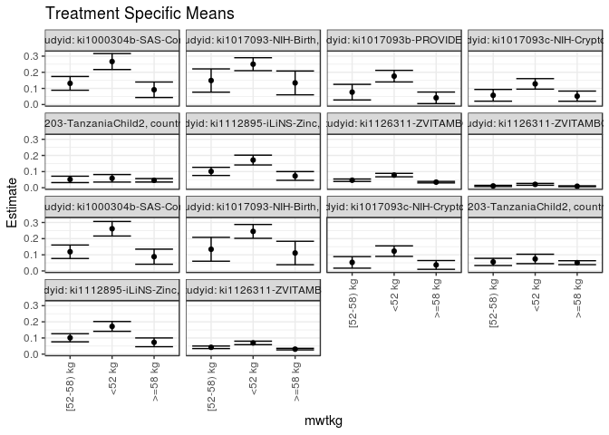

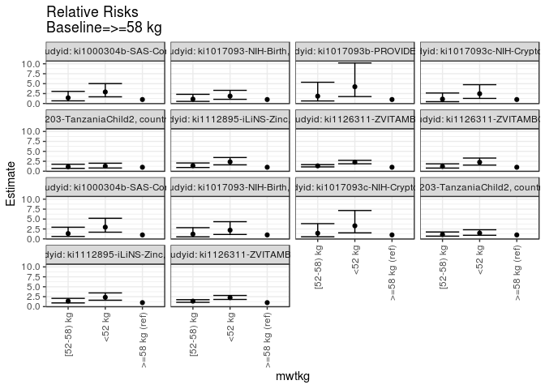

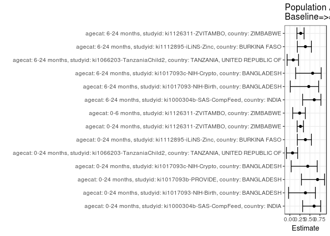

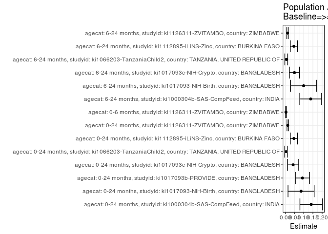

## Results Table

### Parameter: TSM

| agecat | studyid | country | intervention_level | baseline_level | estimate | ci_lower | ci_upper |
| --- | --- | --- | --- | --- | --- | --- | --- |
| 0-24 months | ki1000304b-SAS-CompFeed | INDIA | >=58 kg | NA | 0.0917431 | 0.0437355 | 0.1397508 |
| 0-24 months | ki1000304b-SAS-CompFeed | INDIA | <52 kg | NA | 0.2664931 | 0.2169124 | 0.3160737 |
| 0-24 months | ki1000304b-SAS-CompFeed | INDIA | [52-58) kg | NA | 0.1313559 | 0.0887719 | 0.1739400 |
| 0-24 months | ki1017093-NIH-Birth | BANGLADESH | >=58 kg | NA | 0.1341463 | 0.0603217 | 0.2079709 |
| 0-24 months | ki1017093-NIH-Birth | BANGLADESH | <52 kg | NA | 0.2500000 | 0.2098710 | 0.2901290 |
| 0-24 months | ki1017093-NIH-Birth | BANGLADESH | [52-58) kg | NA | 0.1489362 | 0.0769061 | 0.2209662 |
| 0-24 months | ki1017093b-PROVIDE | BANGLADESH | >=58 kg | NA | 0.0416667 | 0.0058871 | 0.0774462 |
| 0-24 months | ki1017093b-PROVIDE | BANGLADESH | <52 kg | NA | 0.1759259 | 0.1399941 | 0.2118577 |
| 0-24 months | ki1017093b-PROVIDE | BANGLADESH | [52-58) kg | NA | 0.0769231 | 0.0286030 | 0.1252431 |
| 0-24 months | ki1017093c-NIH-Crypto | BANGLADESH | >=58 kg | NA | 0.0520833 | 0.0206334 | 0.0835333 |
| 0-24 months | ki1017093c-NIH-Crypto | BANGLADESH | <52 kg | NA | 0.1280788 | 0.0955514 | 0.1606063 |
| 0-24 months | ki1017093c-NIH-Crypto | BANGLADESH | [52-58) kg | NA | 0.0573248 | 0.0209385 | 0.0937112 |
| 0-24 months | ki1066203-TanzaniaChild2 | TANZANIA, UNITED REPUBLIC OF | >=58 kg | NA | 0.0460705 | 0.0353733 | 0.0567676 |
| 0-24 months | ki1066203-TanzaniaChild2 | TANZANIA, UNITED REPUBLIC OF | <52 kg | NA | 0.0585242 | 0.0353120 | 0.0817364 |
| 0-24 months | ki1066203-TanzaniaChild2 | TANZANIA, UNITED REPUBLIC OF | [52-58) kg | NA | 0.0517598 | 0.0319982 | 0.0715215 |
| 0-24 months | ki1112895-iLiNS-Zinc | BURKINA FASO | >=58 kg | NA | 0.0730397 | 0.0459744 | 0.1001051 |
| 0-24 months | ki1112895-iLiNS-Zinc | BURKINA FASO | <52 kg | NA | 0.1715728 | 0.1412160 | 0.2019295 |
| 0-24 months | ki1112895-iLiNS-Zinc | BURKINA FASO | [52-58) kg | NA | 0.1012299 | 0.0760298 | 0.1264300 |
| 0-24 months | ki1126311-ZVITAMBO | ZIMBABWE | >=58 kg | NA | 0.0347139 | 0.0300103 | 0.0394174 |
| 0-24 months | ki1126311-ZVITAMBO | ZIMBABWE | <52 kg | NA | 0.0783987 | 0.0676397 | 0.0891576 |
| 0-24 months | ki1126311-ZVITAMBO | ZIMBABWE | [52-58) kg | NA | 0.0464880 | 0.0388863 | 0.0540897 |
| 0-6 months | ki1126311-ZVITAMBO | ZIMBABWE | >=58 kg | NA | 0.0093168 | 0.0068433 | 0.0117902 |
| 0-6 months | ki1126311-ZVITAMBO | ZIMBABWE | <52 kg | NA | 0.0210172 | 0.0152529 | 0.0267815 |
| 0-6 months | ki1126311-ZVITAMBO | ZIMBABWE | [52-58) kg | NA | 0.0112436 | 0.0074289 | 0.0150583 |
| 6-24 months | ki1000304b-SAS-CompFeed | INDIA | >=58 kg | NA | 0.0882353 | 0.0415806 | 0.1348900 |
| 6-24 months | ki1000304b-SAS-CompFeed | INDIA | <52 kg | NA | 0.2613208 | 0.2162358 | 0.3064058 |
| 6-24 months | ki1000304b-SAS-CompFeed | INDIA | [52-58) kg | NA | 0.1187215 | 0.0769749 | 0.1604680 |
| 6-24 months | ki1017093-NIH-Birth | BANGLADESH | >=58 kg | NA | 0.1111111 | 0.0384528 | 0.1837694 |
| 6-24 months | ki1017093-NIH-Birth | BANGLADESH | <52 kg | NA | 0.2448454 | 0.2020204 | 0.2876703 |
| 6-24 months | ki1017093-NIH-Birth | BANGLADESH | [52-58) kg | NA | 0.1341463 | 0.0603128 | 0.2079799 |
| 6-24 months | ki1017093c-NIH-Crypto | BANGLADESH | >=58 kg | NA | 0.0372340 | 0.0101510 | 0.0643171 |
| 6-24 months | ki1017093c-NIH-Crypto | BANGLADESH | <52 kg | NA | 0.1227621 | 0.0902124 | 0.1553119 |
| 6-24 months | ki1017093c-NIH-Crypto | BANGLADESH | [52-58) kg | NA | 0.0529801 | 0.0172287 | 0.0887316 |
| 6-24 months | ki1066203-TanzaniaChild2 | TANZANIA, UNITED REPUBLIC OF | >=58 kg | NA | 0.0509960 | 0.0388219 | 0.0631702 |
| 6-24 months | ki1066203-TanzaniaChild2 | TANZANIA, UNITED REPUBLIC OF | <52 kg | NA | 0.0741935 | 0.0450112 | 0.1033759 |
| 6-24 months | ki1066203-TanzaniaChild2 | TANZANIA, UNITED REPUBLIC OF | [52-58) kg | NA | 0.0558252 | 0.0336509 | 0.0779996 |
| 6-24 months | ki1112895-iLiNS-Zinc | BURKINA FASO | >=58 kg | NA | 0.0730397 | 0.0459744 | 0.1001051 |
| 6-24 months | ki1112895-iLiNS-Zinc | BURKINA FASO | <52 kg | NA | 0.1715728 | 0.1412160 | 0.2019295 |
| 6-24 months | ki1112895-iLiNS-Zinc | BURKINA FASO | [52-58) kg | NA | 0.1012299 | 0.0760298 | 0.1264300 |
| 6-24 months | ki1126311-ZVITAMBO | ZIMBABWE | >=58 kg | NA | 0.0308247 | 0.0260316 | 0.0356177 |
| 6-24 months | ki1126311-ZVITAMBO | ZIMBABWE | <52 kg | NA | 0.0693396 | 0.0585256 | 0.0801537 |
| 6-24 months | ki1126311-ZVITAMBO | ZIMBABWE | [52-58) kg | NA | 0.0421990 | 0.0344455 | 0.0499525 |

### Parameter: E(Y)

| agecat | studyid | country | intervention_level | baseline_level | estimate | ci_lower | ci_upper |
| --- | --- | --- | --- | --- | --- | --- | --- |
| 0-24 months | ki1000304b-SAS-CompFeed | INDIA | NA | NA | 0.2324649 | 0.1912705 | 0.2736593 |
| 0-24 months | ki1017093-NIH-Birth | BANGLADESH | NA | NA | 0.2195513 | 0.1870467 | 0.2520558 |
| 0-24 months | ki1017093b-PROVIDE | BANGLADESH | NA | NA | 0.1345291 | 0.1086533 | 0.1604050 |
| 0-24 months | ki1017093c-NIH-Crypto | BANGLADESH | NA | NA | 0.0940397 | 0.0732057 | 0.1148737 |
| 0-24 months | ki1066203-TanzaniaChild2 | TANZANIA, UNITED REPUBLIC OF | NA | NA | 0.0493197 | 0.0405669 | 0.0580726 |
| 0-24 months | ki1112895-iLiNS-Zinc | BURKINA FASO | NA | NA | 0.1192949 | 0.0996089 | 0.1389809 |
| 0-24 months | ki1126311-ZVITAMBO | ZIMBABWE | NA | NA | 0.0472053 | 0.0432711 | 0.0511395 |
| 0-6 months | ki1126311-ZVITAMBO | ZIMBABWE | NA | NA | 0.0123312 | 0.0102790 | 0.0143834 |
| 6-24 months | ki1000304b-SAS-CompFeed | INDIA | NA | NA | 0.2259232 | 0.1899518 | 0.2618946 |
| 6-24 months | ki1017093-NIH-Birth | BANGLADESH | NA | NA | 0.2103321 | 0.1759902 | 0.2446740 |
| 6-24 months | ki1017093c-NIH-Crypto | BANGLADESH | NA | NA | 0.0863014 | 0.0659171 | 0.1066856 |
| 6-24 months | ki1066203-TanzaniaChild2 | TANZANIA, UNITED REPUBLIC OF | NA | NA | 0.0556399 | 0.0455330 | 0.0657467 |
| 6-24 months | ki1112895-iLiNS-Zinc | BURKINA FASO | NA | NA | 0.1192949 | 0.0996089 | 0.1389809 |
| 6-24 months | ki1126311-ZVITAMBO | ZIMBABWE | NA | NA | 0.0422724 | 0.0382678 | 0.0462770 |

### Parameter: RR

| agecat | studyid | country | intervention_level | baseline_level | estimate | ci_lower | ci_upper |
| --- | --- | --- | --- | --- | --- | --- | --- |
| 0-24 months | ki1000304b-SAS-CompFeed | INDIA | >=58 kg | >=58 kg | 1.000000 | 1.0000000 | 1.000000 |
| 0-24 months | ki1000304b-SAS-CompFeed | INDIA | <52 kg | >=58 kg | 2.904774 | 1.6825199 | 5.014926 |
| 0-24 months | ki1000304b-SAS-CompFeed | INDIA | [52-58) kg | >=58 kg | 1.431779 | 0.6726918 | 3.047447 |
| 0-24 months | ki1017093-NIH-Birth | BANGLADESH | >=58 kg | >=58 kg | 1.000000 | 1.0000000 | 1.000000 |
| 0-24 months | ki1017093-NIH-Birth | BANGLADESH | <52 kg | >=58 kg | 1.863636 | 1.0505034 | 3.306168 |
| 0-24 months | ki1017093-NIH-Birth | BANGLADESH | [52-58) kg | >=58 kg | 1.110251 | 0.5336300 | 2.309949 |
| 0-24 months | ki1017093b-PROVIDE | BANGLADESH | >=58 kg | >=58 kg | 1.000000 | 1.0000000 | 1.000000 |
| 0-24 months | ki1017093b-PROVIDE | BANGLADESH | <52 kg | >=58 kg | 4.222222 | 1.7466447 | 10.206516 |
| 0-24 months | ki1017093b-PROVIDE | BANGLADESH | [52-58) kg | >=58 kg | 1.846154 | 0.6370959 | 5.349718 |
| 0-24 months | ki1017093c-NIH-Crypto | BANGLADESH | >=58 kg | >=58 kg | 1.000000 | 1.0000000 | 1.000000 |
| 0-24 months | ki1017093c-NIH-Crypto | BANGLADESH | <52 kg | >=58 kg | 2.459113 | 1.2772751 | 4.734484 |
| 0-24 months | ki1017093c-NIH-Crypto | BANGLADESH | [52-58) kg | >=58 kg | 1.100637 | 0.4583186 | 2.643143 |
| 0-24 months | ki1066203-TanzaniaChild2 | TANZANIA, UNITED REPUBLIC OF | >=58 kg | >=58 kg | 1.000000 | 1.0000000 | 1.000000 |
| 0-24 months | ki1066203-TanzaniaChild2 | TANZANIA, UNITED REPUBLIC OF | <52 kg | >=58 kg | 1.270319 | 0.8022590 | 2.011457 |
| 0-24 months | ki1066203-TanzaniaChild2 | TANZANIA, UNITED REPUBLIC OF | [52-58) kg | >=58 kg | 1.123493 | 0.7186272 | 1.756455 |
| 0-24 months | ki1112895-iLiNS-Zinc | BURKINA FASO | >=58 kg | >=58 kg | 1.000000 | 1.0000000 | 1.000000 |
| 0-24 months | ki1112895-iLiNS-Zinc | BURKINA FASO | <52 kg | >=58 kg | 2.349033 | 1.6025580 | 3.443217 |
| 0-24 months | ki1112895-iLiNS-Zinc | BURKINA FASO | [52-58) kg | >=58 kg | 1.385956 | 0.9254387 | 2.075637 |
| 0-24 months | ki1126311-ZVITAMBO | ZIMBABWE | >=58 kg | >=58 kg | 1.000000 | 1.0000000 | 1.000000 |
| 0-24 months | ki1126311-ZVITAMBO | ZIMBABWE | <52 kg | >=58 kg | 2.258425 | 1.8623074 | 2.738798 |
| 0-24 months | ki1126311-ZVITAMBO | ZIMBABWE | [52-58) kg | >=58 kg | 1.339175 | 1.0829541 | 1.656017 |
| 0-6 months | ki1126311-ZVITAMBO | ZIMBABWE | >=58 kg | >=58 kg | 1.000000 | 1.0000000 | 1.000000 |
| 0-6 months | ki1126311-ZVITAMBO | ZIMBABWE | <52 kg | >=58 kg | 2.255850 | 1.5400521 | 3.304342 |
| 0-6 months | ki1126311-ZVITAMBO | ZIMBABWE | [52-58) kg | >=58 kg | 1.206814 | 0.7844137 | 1.856674 |
| 6-24 months | ki1000304b-SAS-CompFeed | INDIA | >=58 kg | >=58 kg | 1.000000 | 1.0000000 | 1.000000 |
| 6-24 months | ki1000304b-SAS-CompFeed | INDIA | <52 kg | >=58 kg | 2.961635 | 1.6894052 | 5.191934 |
| 6-24 months | ki1000304b-SAS-CompFeed | INDIA | [52-58) kg | >=58 kg | 1.345510 | 0.6164229 | 2.936939 |
| 6-24 months | ki1017093-NIH-Birth | BANGLADESH | >=58 kg | >=58 kg | 1.000000 | 1.0000000 | 1.000000 |
| 6-24 months | ki1017093-NIH-Birth | BANGLADESH | <52 kg | >=58 kg | 2.203608 | 1.1198381 | 4.336242 |
| 6-24 months | ki1017093-NIH-Birth | BANGLADESH | [52-58) kg | >=58 kg | 1.207317 | 0.5135934 | 2.838071 |
| 6-24 months | ki1017093c-NIH-Crypto | BANGLADESH | >=58 kg | >=58 kg | 1.000000 | 1.0000000 | 1.000000 |
| 6-24 months | ki1017093c-NIH-Crypto | BANGLADESH | <52 kg | >=58 kg | 3.297041 | 1.5201868 | 7.150750 |
| 6-24 months | ki1017093c-NIH-Crypto | BANGLADESH | [52-58) kg | >=58 kg | 1.422895 | 0.5275590 | 3.837732 |
| 6-24 months | ki1066203-TanzaniaChild2 | TANZANIA, UNITED REPUBLIC OF | >=58 kg | >=58 kg | 1.000000 | 1.0000000 | 1.000000 |
| 6-24 months | ki1066203-TanzaniaChild2 | TANZANIA, UNITED REPUBLIC OF | <52 kg | >=58 kg | 1.454889 | 0.9183508 | 2.304895 |
| 6-24 months | ki1066203-TanzaniaChild2 | TANZANIA, UNITED REPUBLIC OF | [52-58) kg | >=58 kg | 1.094698 | 0.6886994 | 1.740039 |
| 6-24 months | ki1112895-iLiNS-Zinc | BURKINA FASO | >=58 kg | >=58 kg | 1.000000 | 1.0000000 | 1.000000 |
| 6-24 months | ki1112895-iLiNS-Zinc | BURKINA FASO | <52 kg | >=58 kg | 2.349033 | 1.6025580 | 3.443217 |
| 6-24 months | ki1112895-iLiNS-Zinc | BURKINA FASO | [52-58) kg | >=58 kg | 1.385956 | 0.9254387 | 2.075637 |
| 6-24 months | ki1126311-ZVITAMBO | ZIMBABWE | >=58 kg | >=58 kg | 1.000000 | 1.0000000 | 1.000000 |
| 6-24 months | ki1126311-ZVITAMBO | ZIMBABWE | <52 kg | >=58 kg | 2.249485 | 1.8048402 | 2.803675 |
| 6-24 months | ki1126311-ZVITAMBO | ZIMBABWE | [52-58) kg | >=58 kg | 1.369001 | 1.0761394 | 1.741562 |

### Parameter: PAR

| agecat | studyid | country | intervention_level | baseline_level | estimate | ci_lower | ci_upper |
| --- | --- | --- | --- | --- | --- | --- | --- |
| 0-24 months | ki1000304b-SAS-CompFeed | INDIA | >=58 kg | NA | 0.1407218 | 0.0790403 | 0.2024033 |
| 0-24 months | ki1017093-NIH-Birth | BANGLADESH | >=58 kg | NA | 0.0854049 | 0.0141713 | 0.1566386 |
| 0-24 months | ki1017093b-PROVIDE | BANGLADESH | >=58 kg | NA | 0.0928625 | 0.0542558 | 0.1314692 |
| 0-24 months | ki1017093c-NIH-Crypto | BANGLADESH | >=58 kg | NA | 0.0419564 | 0.0116234 | 0.0722894 |
| 0-24 months | ki1066203-TanzaniaChild2 | TANZANIA, UNITED REPUBLIC OF | >=58 kg | NA | 0.0032493 | -0.0036371 | 0.0101356 |
| 0-24 months | ki1112895-iLiNS-Zinc | BURKINA FASO | >=58 kg | NA | 0.0462552 | 0.0264976 | 0.0660127 |
| 0-24 months | ki1126311-ZVITAMBO | ZIMBABWE | >=58 kg | NA | 0.0124914 | 0.0086785 | 0.0163044 |
| 0-6 months | ki1126311-ZVITAMBO | ZIMBABWE | >=58 kg | NA | 0.0030145 | 0.0010280 | 0.0050009 |
| 6-24 months | ki1000304b-SAS-CompFeed | INDIA | >=58 kg | NA | 0.1376879 | 0.0782047 | 0.1971712 |
| 6-24 months | ki1017093-NIH-Birth | BANGLADESH | >=58 kg | NA | 0.0992210 | 0.0281155 | 0.1703265 |
| 6-24 months | ki1017093c-NIH-Crypto | BANGLADESH | >=58 kg | NA | 0.0490673 | 0.0212967 | 0.0768380 |
| 6-24 months | ki1066203-TanzaniaChild2 | TANZANIA, UNITED REPUBLIC OF | >=58 kg | NA | 0.0046438 | -0.0032423 | 0.0125300 |
| 6-24 months | ki1112895-iLiNS-Zinc | BURKINA FASO | >=58 kg | NA | 0.0462552 | 0.0264976 | 0.0660127 |
| 6-24 months | ki1126311-ZVITAMBO | ZIMBABWE | >=58 kg | NA | 0.0114477 | 0.0075308 | 0.0153647 |

### Parameter: PAF

| agecat | studyid | country | intervention_level | baseline_level | estimate | ci_lower | ci_upper |
| --- | --- | --- | --- | --- | --- | --- | --- |
| 0-24 months | ki1000304b-SAS-CompFeed | INDIA | >=58 kg | NA | 0.6053464 | 0.3200264 | 0.7709448 |
| 0-24 months | ki1017093-NIH-Birth | BANGLADESH | >=58 kg | NA | 0.3889977 | -0.0333865 | 0.6387375 |
| 0-24 months | ki1017093b-PROVIDE | BANGLADESH | >=58 kg | NA | 0.6902778 | 0.2881910 | 0.8652337 |
| 0-24 months | ki1017093c-NIH-Crypto | BANGLADESH | >=58 kg | NA | 0.4461561 | 0.0326597 | 0.6829006 |
| 0-24 months | ki1066203-TanzaniaChild2 | TANZANIA, UNITED REPUBLIC OF | >=58 kg | NA | 0.0658817 | -0.0842056 | 0.1951923 |
| 0-24 months | ki1112895-iLiNS-Zinc | BURKINA FASO | >=58 kg | NA | 0.3877381 | 0.1864500 | 0.5392236 |
| 0-24 months | ki1126311-ZVITAMBO | ZIMBABWE | >=58 kg | NA | 0.2646193 | 0.1824082 | 0.3385638 |
| 0-6 months | ki1126311-ZVITAMBO | ZIMBABWE | >=58 kg | NA | 0.2444575 | 0.0712194 | 0.3853829 |
| 6-24 months | ki1000304b-SAS-CompFeed | INDIA | >=58 kg | NA | 0.6094456 | 0.3194937 | 0.7758541 |
| 6-24 months | ki1017093-NIH-Birth | BANGLADESH | >=58 kg | NA | 0.4717349 | 0.0102035 | 0.7180592 |
| 6-24 months | ki1017093c-NIH-Crypto | BANGLADESH | >=58 kg | NA | 0.5685579 | 0.1453269 | 0.7822065 |
| 6-24 months | ki1066203-TanzaniaChild2 | TANZANIA, UNITED REPUBLIC OF | >=58 kg | NA | 0.0834625 | -0.0689736 | 0.2141612 |
| 6-24 months | ki1112895-iLiNS-Zinc | BURKINA FASO | >=58 kg | NA | 0.3877381 | 0.1864500 | 0.5392236 |
| 6-24 months | ki1126311-ZVITAMBO | ZIMBABWE | >=58 kg | NA | 0.2708088 | 0.1758383 | 0.3548357 |